# Course Project - Activity Monitoring data

## Loading and preprocessing the data

Read the “activity” datapack

```r
activity <- read.csv("activity.csv",header=TRUE)
```

Format second columns as Date

```r
factortocharacter <- as.character(activity[,2])
activity[,2] <- as.Date(factortocharacter,format="%Y-%m-%d")
```

## What is mean total number of steps taken per day?

```r
totalsteps <- aggregate(activity$steps, by=list(Date=activity$date), FUN=sum)
```

Histogram of the total number of steps taken each day

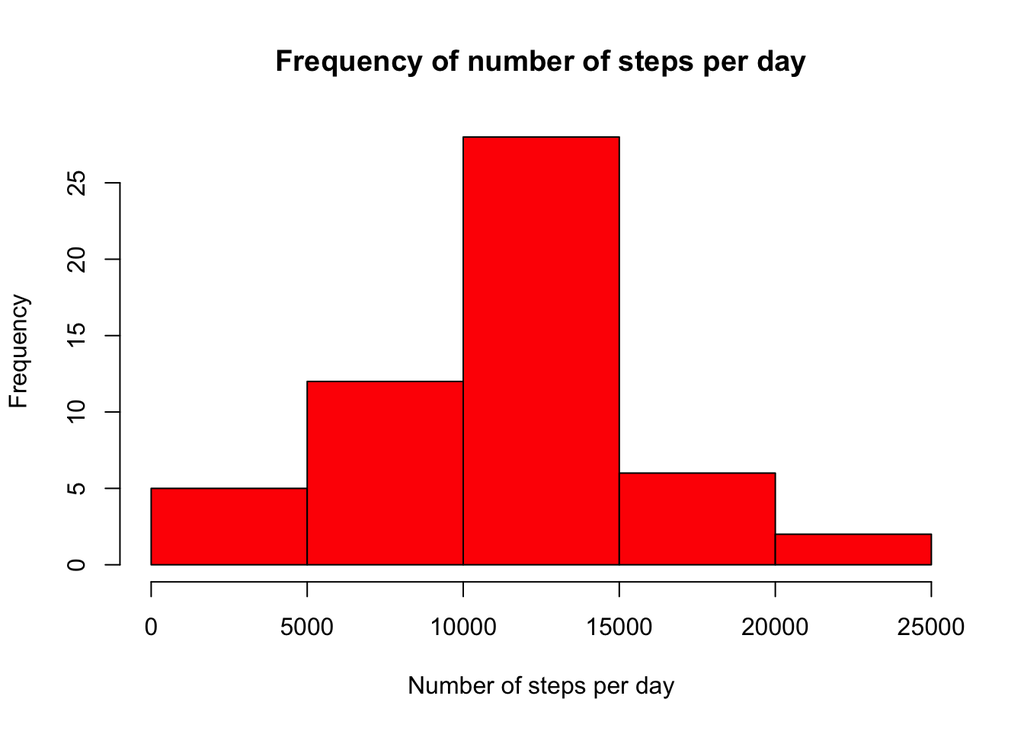

```r
hist(totalsteps$x, breaks = 6, main = "Frequency of number of steps per day",
    xlab = "Number of steps per day", ylab = "Frequency", col = "red")
```

```r
mean(totalsteps$x,na.rm=TRUE)
```

```
## [1] 10766.19
```

```r
median(totalsteps$x,na.rm=TRUE)
```

```
## [1] 10765
```

## What is the average daily activity pattern?

Make a time series plot (i.e. 𝚝𝚢𝚙𝚎 = “𝚕”) of the 5-minute interval (x-axis) and the average number of steps taken, averaged across all days (y-axis)

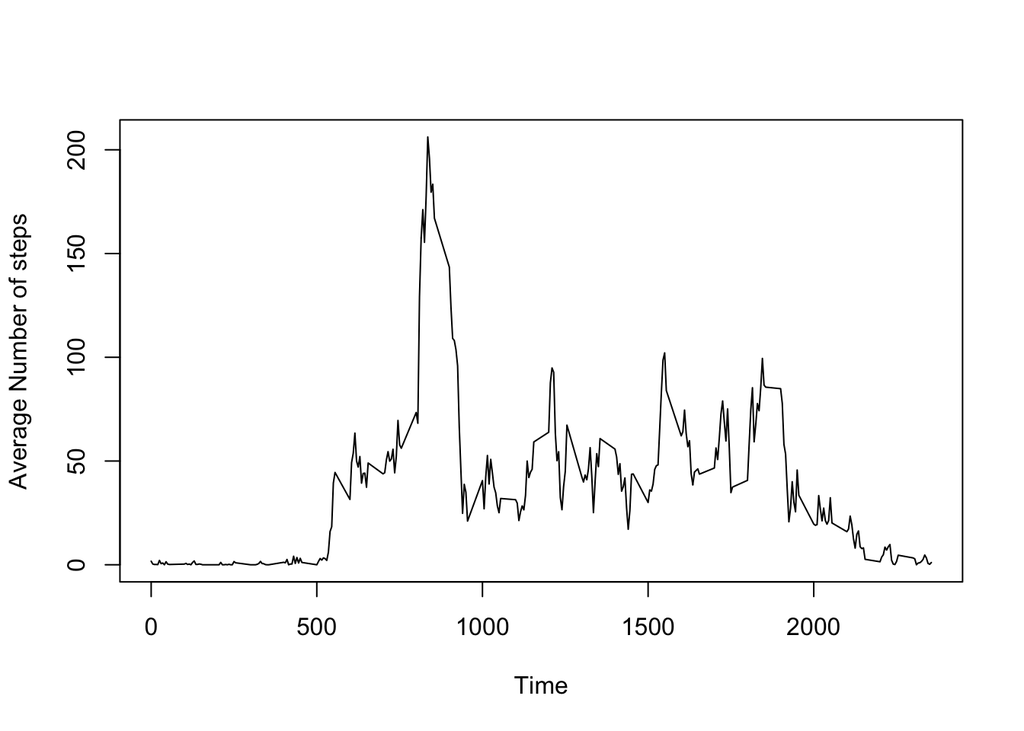

```r
averagestepstime <- aggregate(activity$steps,by=list(Interval=activity$interval),FUN=mean,na.rm=TRUE)
plot(averagestepstime,type="l",xlab="Time",ylab="Average Number of steps")
```

Which 5-minute interval, on average across all the days in the dataset, contains the maximum number of steps?

```r
maxsteps <- max(averagestepstime$x)
averagestepstime$Interval[averagestepstime$x==maxsteps]
```

```
## [1] 835
```

The interval from 8:35 to 8:40

## Imputing missing values

Number of NA value in activity datafram

```r
sum(is.na(activity$steps))
```

```
## [1] 2304
```

Devise a strategy for filling in all of the missing values in the dataset

*I will fill the NA with average value for that 5-min interval*

Create a new dataset that is equal to the original dataset but with the missing data filled in.

```r
imputed <- activity

for (i in 1:nrow(imputed)) {
    if(is.na(imputed$steps[i])){
        imputed$steps[i] <- averagestepstime$x[which(imputed$interval[i] == averagestepstime$Interval)]}
}
```

Make a histogram of the total number of steps taken each day

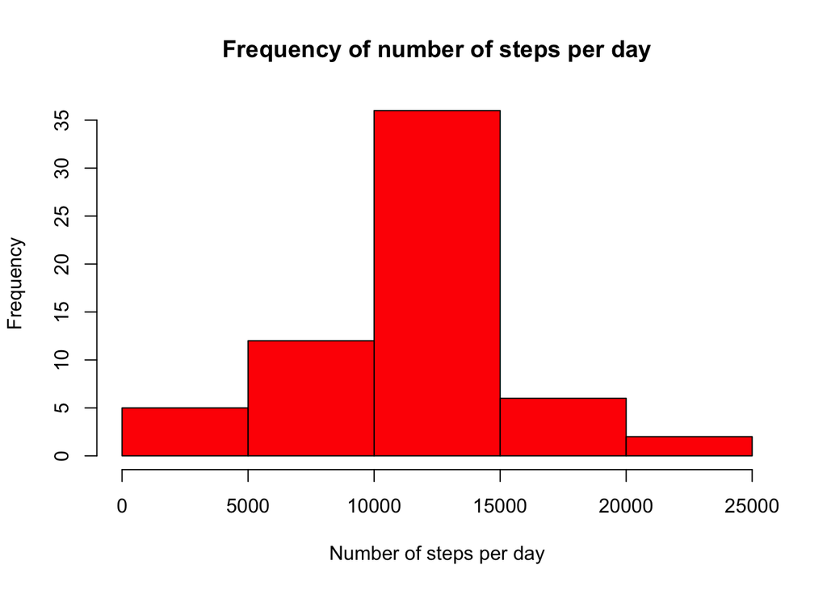

```r
totalstepsimputed <- aggregate(imputed$steps, by=list(Date=imputed$date), FUN=sum)
hist(totalstepsimputed$x, breaks = 6, main = "Frequency of number of steps per day", xlab = "Number of steps per day", ylab = "Frequency", col = "red")
```

Calculate and report the mean

```r
mean(totalstepsimputed$x)
```

```
## [1] 10766.19
```

Calculate and report the median

```r
median(totalstepsimputed$x)
```

```
## [1] 10766.19
```

Do these values differ from the estimates from the first part of the assignment?

```r
mean(totalstepsimputed$x)-mean(totalsteps$x,na.rm=TRUE)
```

```
## [1] 0
```

Mean does not change between the two datasets

```r
median(totalstepsimputed$x)-median(totalsteps$x,na.rm=TRUE)
```

```
## [1] 1.188679
```

Median change between the two different datasets

```r
sum(totalstepsimputed$x) - sum(totalsteps$x,na.rm=TRUE)
```

```
## [1] 86129.51
```

The new datasets take 86K+ more steps into account